# Using the “forecastHybrid” package

David Shaub

2016-06-01

The “forecastHybrid” package provides functions to build composite models using multiple individual component models from the “forecast” package. These `hybridModel` objects can then be manipulated with many of the familiar functions from the “forecast” and “stats” packages including `forecast()`, `plot()`, `accuracy()`, `residuals()`, and `fitted()`.

# Installation

The stable release of the package is hosted on [CRAN](https://cran.r-project.org/web/packages/forecastHybrid/index.html) and can be installed as usual.

```r
install.packages("forecastHybrid")
```

The latest development version can be installed using the “devtools”" package.

```r
devtools::install_github("ellisp/forecastHybrid/pkg")
```

Version updates to CRAN will be published frequently after new features are implemented, so the development version is not recommended unless you plan to modify the code.

# Basic usage

First load the package.

```r
library(forecastHybrid)
```

## Quick start

If you don’t have time to read the whole guide and want to get started immediatly with sane default settings to forecast the `AirPassengers` timeseries, run the following:

```r
quickModel <- hybridModel(AirPassengers)
forecast(quickModel)
```

```
##          Point Forecast    Lo 80    Hi 80    Lo 95    Hi 95
## Jan 1961       448.8942 420.9284 474.4528 409.9071 486.2105
## Feb 1961       430.3533 402.5180 463.4376 392.8622 477.7219
## Mar 1961       476.4147 427.8241 541.2952 416.7423 560.7848
## Apr 1961       489.5884 445.6985 533.1953 425.6737 554.8180
## May 1961       499.2229 443.0128 546.2434 420.7317 570.5889
## Jun 1961       565.6039 498.8558 624.6220 471.1949 654.7751
## Jul 1961       643.3428 550.5136 710.4620 517.2336 747.2133
## Aug 1961       635.2194 543.3613 713.0508 507.8542 752.2024
## Sep 1961       544.7448 468.8133 632.2052 435.9204 668.8588
## Oct 1961       486.8565 405.1625 557.1301 374.8081 591.0168
## Nov 1961       424.2436 349.4447 494.6448 321.6167 526.0871
## Dec 1961       467.4054 388.8923 560.4230 356.0996 597.5240
## Jan 1962       484.5343 392.2920 586.0717 357.3798 626.2887
## Feb 1962       467.6296 381.4061 580.0403 345.6841 621.2372
## Mar 1962       516.2353 424.9010 673.9258 391.0899 723.3987
## Apr 1962       530.2640 418.8586 661.0549 375.7208 711.1125
## May 1962       540.7499 416.8132 674.9179 371.9359 727.5080
## Jun 1962       612.3375 469.7070 769.4987 416.9301 831.1089
## Jul 1962       693.7987 518.5862 873.0125 457.8729 944.7378
## Aug 1962       684.9865 511.9731 874.2538 449.6093 947.8275
## Sep 1962       589.3781 441.7638 773.5659 385.8483 840.2075
## Oct 1962       527.5933 381.7623 680.4912 331.6121 740.4049
## Nov 1962       461.7116 329.2070 603.1846 284.3727 657.4195
## Dec 1962       506.3358 366.2764 682.3729 314.6143 744.9800
```

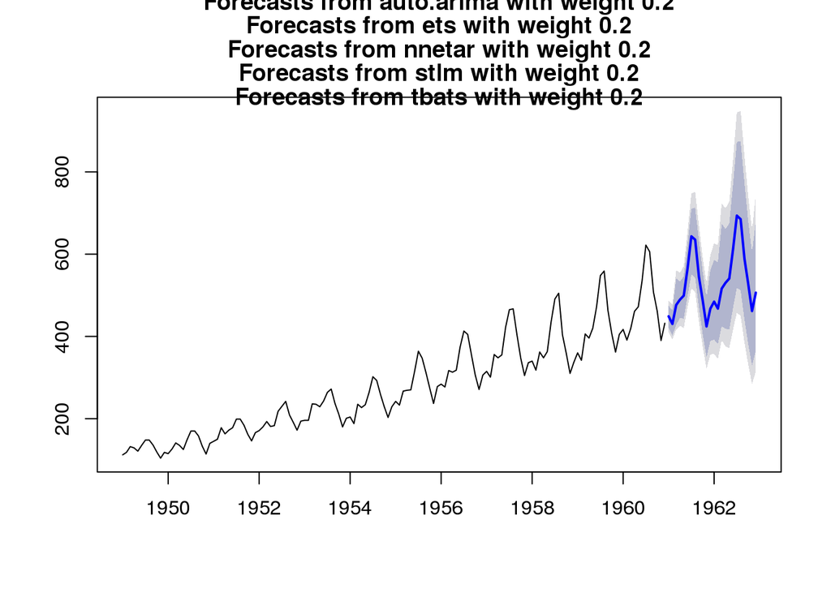

```r
plot(forecast(quickModel))
```

## Fitting a model

The workhorse function of the package is `hybridModel()`, a function that combines several component models from the “forecast” package. At a minimum, the user must supply a `ts` or `numeric` vector for `y`. In this case, the ensemble will include all of the component models: `auto.arima()`, `ets()`, `nnetar()`, `stlm()`, and `tbats()`. To instead use only a subset of these models, pass a character string to the `models` argument with the first letter of each model to include. For example, to build an ensemble model on the `gas` dataset with `auto.arima()`, `ets()`, and `tbats()` components, run

```r
# Build a hybrid forecast on the gas dataset using auto.arima, ets, and tbats models.
# Each model is given equal weight
hm1 <- hybridModel(y = gas, models = "aet", weights = "equal")
```

The individual component models are stored inside the `hybridModel` objects and can viewed in their respective slots, and all the regular methods from the “forecast” package could be applied to these individual component models.

```r
# View the individual models
hm1$auto.arima
```

```
## Series: structure(c(1709, 1646, 1794, 1878, 2173, 2321, 2468, 2416, 2184,  2121, 1962, 1825, 1751, 1688, 1920, 1941, 2311, 2279, 2638, 2448,  2279, 2163, 1941, 1878, 1773, 1688, 1783, 1984, 2290, 2511, 2712,  2522, 2342, 2195, 1931, 1910, 1730, 1688, 1899, 1994, 2342, 2553,  2712, 2627, 2363, 231…
## ARIMA(2,1,1)(1,0,0)[12]
##
## Coefficients:
##          ar1     ar2      ma1    sar1
##       0.5117  0.1824  -0.9638  0.8478
## s.e.  0.0502  0.0498   0.0134  0.0277
##
## sigma^2 estimated as 3201509:  log likelihood=-4236.9
## AIC=8483.81   AICc=8483.94   BIC=8504.63
```

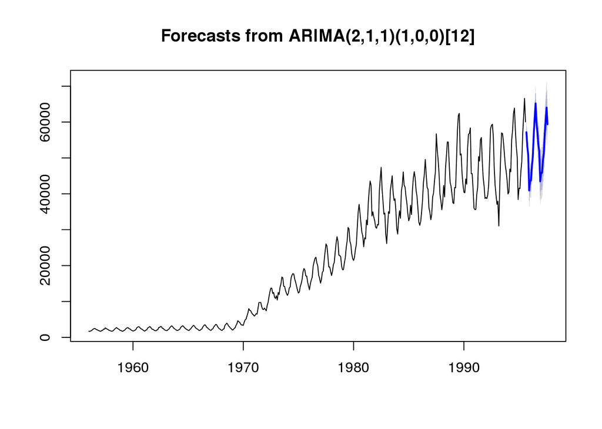

```r
# See forecasts from the auto.arima model
plot(forecast(hm1$auto.arima))
```

### Model diagnostics

```r
class(hm1)
```

```
## [1] "hybridModel"
```

```r
is.hybridModel(hm1)
```

```
## [1] TRUE
```

The `print()` and `summary()` methods print information about the ensemble model including the weights assigned to each individual component model.

```r
print(hm1)
```

```
## Hybrid forecast model comprised of the following models: auto.arima, ets, tbats
## ############
## auto.arima with weight 0.3333333
## ############
## ets with weight 0.3333333
## ############
## tbats with weight 0.3333333
```

```r
summary(hm1)
```

```
##            Length Class  Mode
## auto.arima  16    ARIMA  list
## ets         18    ets    list
## tbats       23    tbats  list
## weights      3    -none- numeric
## frequency    1    -none- numeric
## x          476    ts     numeric
## models       3    -none- character
## fitted     476    ts     numeric
## residuals  476    ts     numeric
```

Two types of plots can be created for the created ensemble model: either a plot showing the actual and fitted value of each component model on the data or individual plots of the component models as created by their regular S3 `plot()` methods. Note that a `plot()` method does not exist in the “forecast” package for objects generated with `stlm()`, so this component model will be ignored when `type = "models"`, but the other component models will be plotted regardless.

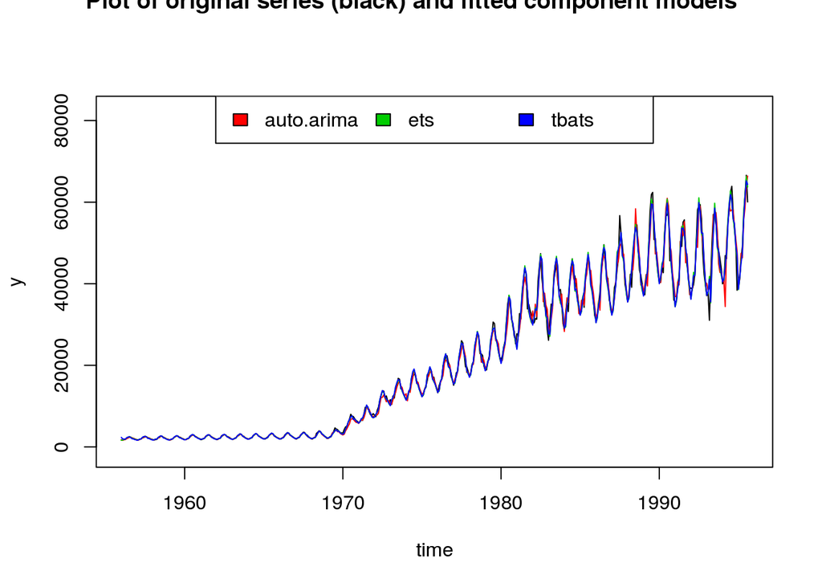

```r
plot(hm1, type = "fit")
```